# Chess dataset

Jan Pryl

2023-11-29

# Wprowadzenie

Zbiór danych orginalnie posiada 15 mln wierszy, niestety jest to za dużo i uniemożliwia to pracę z tymi danymi więc zredukowałem je do 1048575 rekordów. Dane pobrałem ze strony: *https://www.kaggle.com/datasets/maca11/chess-games-from-lichess-20132014*

Każdy wpis opisuje partię szachową ze strony lichess w latach 2013 i 2014.

## Zmienne

- **Ranking białego gracza** (liczba)
- **Ranking czarnego gracza** (liczba)
- **Zwycięzca** (tekst: biały/czarny)
- **Zakończenie** (tekst: powód zakończenia partii)
- **Miesiąc** (liczba)
- **Rok** (liczba)
- **Czas początkowy** (liczba: czas każdego z graczy na początku gry)
- **Przyrost czasu** (liczba: przyrost czasu z każdym ruchem)
- **Tempo gry** (tekst: podział czasu poczatkowego i przyrostu czasu na 4 kategorie)
- **Otwarcie** (tekst: nazwa otwarcia)
- **ECO** (tekst: kod otwarcia z encyklopedii otwarć szachowych)
- **Liczba ruchów** (liczba: liczba ruchów wykonanych podczas partii)

## Używane pakiety

```r
library(tidyverse)
library(mice)
library(scales)
library(corrplot)
library(readxl)
```

## Dane i ich struktura

Zacznijmy od wczytania pliku do R.

```r
chess <- read_excel("chess.xlsx")
```

Sprawdźmy strukturę danych.

```r
str(chess)
```

```
## tibble [1,048,575 × 12] (S3: tbl_df/tbl/data.frame)
##  $ WhiteElo       : num [1:1048575] 1516 1242 1543 1616 1907 ...
##  $ BlackElo       : num [1:1048575] 1480 1561 1575 1436 1561 ...
##  $ Winner         : chr [1:1048575] "White" "Black" "Draw" "White" ...
##  $ Termination    : chr [1:1048575] "Time forfeit" "Time forfeit" "Normal" "Time forfeit" ...
##  $ Month          : num [1:1048575] 1 1 1 1 1 1 1 1 1 1 ...
##  $ Year           : num [1:1048575] 2013 2013 2013 2013 2013 ...
##  $ InitialTime    : num [1:1048575] 60 0 0 300 60 60 0 60 60 180 ...
##  $ Increment      : num [1:1048575] 0 1 1 0 0 0 1 0 0 0 ...
##  $ TimeControl    : chr [1:1048575] "Bullet" "Bullet" "Bullet" "Blitz" ...
##  $ Opening        : chr [1:1048575] "Modern Defense" "Horwitz Defense" "Gedult's Opening" "Scandinavian Defense: Mieses-Kotroc Variation" ...
##  $ ECO            : chr [1:1048575] "B06" "A40" "A00" "B01" ...
##  $ Number_of_Moves: num [1:1048575] 28 19 70 32 8 57 12 35 17 24 ...
```

Zmieńmy dane typu character na typ **faktor**.

```r
chess$ECO <- as.factor(chess$ECO)
chess$TimeControl <- as.factor(chess$TimeControl)
chess$Opening <- as.factor(chess$Opening)
chess$Winner <- as.factor(chess$Winner)
chess$Termination <- as.factor(chess$Termination)
```

Zmieńmy nazwy kolumn na polskie.

```r
nazwy <- c("Ranking_biały", "Ranking_czarny", "Zwycięzca", "Zakończenie", "Miesiąc", "Rok", "Czas_początkowy", "Przyrost_czasu", "Tempo_gry", "Otwarcie", "ECO", "Liczba_ruchów")
names(chess) <- nazwy
```

Teraz dodajmy kilka kolumn, przydadzą sie one później.

Kolumna **data**(miesiąc i rok):

```r
Data <- paste(chess$Rok, chess$Miesiąc, sep = "-")
Data <- paste(Data, "01", sep = "-")
Data <- as.Date(Data)
Data <- format(Data, "%Y-%m")
chess <- cbind(chess, Data)
chess$Data <- as.factor(chess$Data)
```

Kolumna pokazująca średni **ranking** czarnego i białego gracza:

```r
Ranking <- (chess$Ranking_biały + chess$Ranking_czarny)/2
chess <- cbind(chess, Ranking)
```

Od razu dodajmy **kategorie rankingu** dzieląc go na *niski*, *średni* i *wysoki*.

```r
chess<-chess%>%
  mutate(Ranking_kat = case_when(
    Ranking >= 2000 ~ "Wysoki",Ranking < 1300 ~ "Niski",Ranking < 2000 ~ "Średni"
  ))
chess$Ranking_kat <- as.factor(chess$Ranking_kat)
```

Kolumna dzieląca **otwarcia** na ich typ (za pomocą *ECO*):

```r
liczby1<-c("00","01","02","03","04","05","06","07","08","09")
liczby2 <- c(liczby1, 10:99)
Flank_opening <- paste0("A", liczby2)

Semi_open <- paste0("B", liczby2)
Semi_open <- c(Semi_open, "C00", "C01", "C02", "C03", "C04", "C10", "C11", "C12", "C13",
               "C14", "C15", "C16", "C17", "C18", "C19")

Open_games <- paste0("C", 20:99)
Open_games <- c(Open_games, "C07", "C08","C09")

liczby3 <- c(liczby1, 10:69)
Closed_games <- paste0("D", liczby3)
Closed_games <- c(Closed_games, "C05", "C06")

Semi_closed <- paste0("D", 70:99)

Indian_games <- paste0("E", liczby2)

chess<-chess%>%
  mutate(Typ_otwarcia = case_when(
    ECO %in% Flank_opening ~ "Flank",ECO %in% Open_games ~ "Open",
    ECO %in% Closed_games ~ "Closed",ECO %in% Semi_open ~ "Semi-open",
    ECO %in% Semi_closed ~ "Semi-closed",ECO %in% Indian_games ~ "Indian"
  ))

chess$Typ_otwarcia <- as.factor(chess$Typ_otwarcia)
```

Teraz możemy kontynuować sprawdzanie danych :).

Jeszcze raz użyjmy funkcji *str()*.

```r
str(chess)
```

```
## 'data.frame':    1048575 obs. of  16 variables:
##  $ Ranking_biały  : num  1516 1242 1543 1616 1907 ...
##  $ Ranking_czarny : num  1480 1561 1575 1436 1561 ...
##  $ Zwycięzca      : Factor w/ 3 levels "Black","Draw",..: 3 1 2 3 3 1 3 3 1 3 ...
##  $ Zakończenie    : Factor w/ 4 levels "Abandoned","Normal",..: 4 4 2 4 2 4 2 4 2 4 ...
##  $ Miesiąc        : num  1 1 1 1 1 1 1 1 1 1 ...
##  $ Rok            : num  2013 2013 2013 2013 2013 ...
##  $ Czas_początkowy: num  60 0 0 300 60 60 0 60 60 180 ...
##  $ Przyrost_czasu : num  0 1 1 0 0 0 1 0 0 0 ...
##  $ Tempo_gry      : Factor w/ 4 levels "Blitz","Bullet",..: 2 2 2 1 2 2 2 2 2 1 ...
##  $ Otwarcie       : Factor w/ 2640 levels "Alekhine Defense",..: 1255 773 711 2060 58 2290 1248 2128 572 1417 ...
##  $ ECO            : Factor w/ 487 levels "A00","A01","A02",..: 104 41 1 99 98 119 1 342 198 44 ...
##  $ Liczba_ruchów  : num  28 19 70 32 8 57 12 35 17 24 ...
##  $ Data           : Factor w/ 24 levels "2013-01","2013-02",..: 1 1 1 1 1 1 1 1 1 1 ...
##  $ Ranking        : num  1498 1402 1559 1526 1734 ...
##  $ Ranking_kat    : Factor w/ 3 levels "Niski","Średni",..: 2 2 2 2 2 2 2 2 2 2 ...
##  $ Typ_otwarcia   : Factor w/ 6 levels "Closed","Flank",..: 6 2 2 6 6 6 2 1 6 2 ...
```

```r
dim(chess)
```

```
## [1] 1048575      16
```

Widzimy że dane mają 1048575 wierszy oraz 16 kolumn.

Wyświetlmy teraz podstawowe statystyki opisowe za pomocą funkcji *summary()*.

```r
summary(chess)
```

```
##  Ranking_biały  Ranking_czarny Zwycięzca                Zakończenie
##  Min.   : 765   Min.   : 766   Black:482804   Abandoned       :   552
##  1st Qu.:1471   1st Qu.:1463   Draw : 36294   Normal          :700541
##  Median :1620   Median :1611   White:529477   Rules infraction:    95
##  Mean   :1624   Mean   :1616                  Time forfeit    :347387
##  3rd Qu.:1774   3rd Qu.:1769
##  Max.   :2955   Max.   :2969
##
##     Miesiąc            Rok       Czas_początkowy Przyrost_czasu
##  Min.   : 1.000   Min.   :2013   Min.   :    0   Min.   :  0.000
##  1st Qu.: 5.000   1st Qu.:2014   1st Qu.:  120   1st Qu.:  0.000
##  Median : 8.000   Median :2014   Median :  300   Median :  0.000
##  Mean   : 7.314   Mean   :2014   Mean   :  308   Mean   :  2.344
##  3rd Qu.:10.000   3rd Qu.:2014   3rd Qu.:  360   3rd Qu.:  3.000
##  Max.   :12.000   Max.   :2014   Max.   :10800   Max.   :180.000
##
##      Tempo_gry                                               Otwarcie
##  Blitz    :421557   Van't Kruijs Opening                         : 27903
##  Bullet   :298245   Modern Defense                               : 19701
##  Classical: 21770   Horwitz Defense                              : 19597
##  Rapid    :307003   Scandinavian Defense: Mieses-Kotroc Variation: 18013
##                     Owen Defense                                 : 17286
##                     French Defense: Knight Variation             : 15973
##                     (Other)                                      :930102
##       ECO         Liczba_ruchów         Data           Ranking
##  A00    : 82557   Min.   :  1.00   2014-11: 86092   Min.   : 830.5
##  C00    : 57982   1st Qu.: 23.00   2014-10: 79083   1st Qu.:1476.0
##  A40    : 54573   Median : 32.00   2014-12: 77820   Median :1613.0
##  D00    : 44124   Mean   : 33.85   2014-07: 74684   Mean   :1619.9
##  B01    : 43488   3rd Qu.: 43.00   2014-08: 72168   3rd Qu.:1756.5
##  B00    : 41504   Max.   :188.00   2014-09: 71234   Max.   :2674.5
##  (Other):724347                    (Other):587494
##  Ranking_kat          Typ_otwarcia
##  Niski : 59069   Closed     :134915
##  Średni:947420   Flank      :268193
##  Wysoki: 42086   Indian     : 17229
##                  Open       :260949
##                  Semi-closed:  2519
##                  Semi-open  :364770
##
```

Następnie sprawdźmy ewentualne *braki danych*.

```
##  /\     /\
## {  `---'  }
## {  O   O  }
## ==>  V <==  No need for mice. This data set is completely observed.
##  \  \|/  /
##   `-----'
```

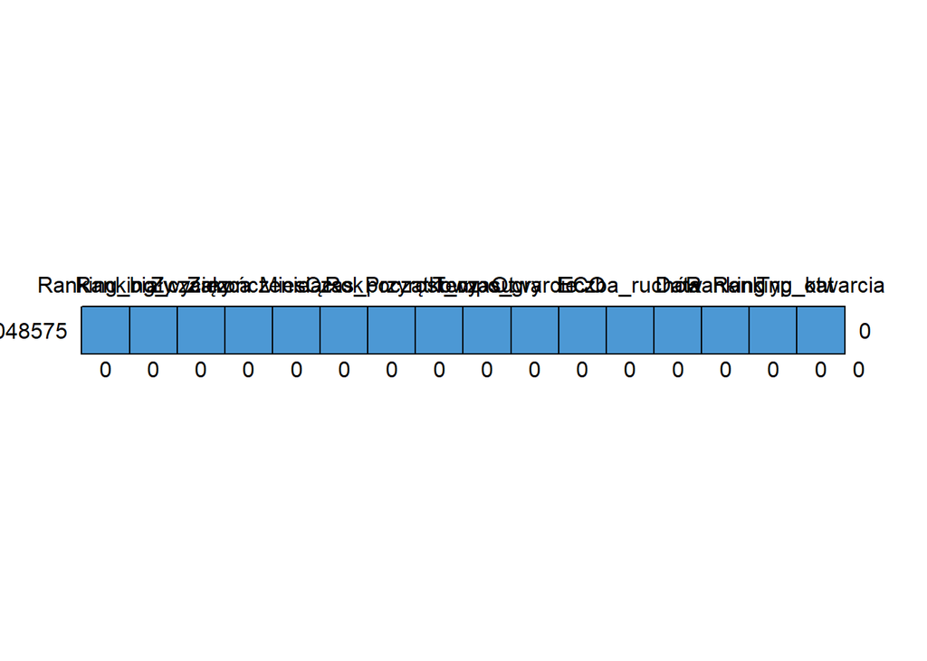

```
##         Ranking_biały Ranking_czarny Zwycięzca Zakończenie Miesiąc Rok
## 1048575             1              1         1           1       1   1
##                     0              0         0           0       0   0
##         Czas_początkowy Przyrost_czasu Tempo_gry Otwarcie ECO Liczba_ruchów
## 1048575               1              1         1        1   1             1
##                       0              0         0        0   0             0
##         Data Ranking Ranking_kat Typ_otwarcia
## 1048575    1       1           1            1 0
##            0       0           0            0 0
```

```r
md.pattern(chess)
```

Nie ma braków - nie ma problemu.

## Czas na kilka wykresów

Zacznijmy od wykresu **gęstości rankingu**.

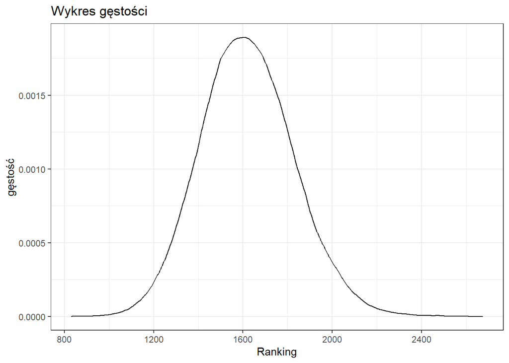

```r
chess %>%
  ggplot(aes(Ranking)) +
  geom_density() +
  theme_bw()+
  labs(title = "Wykres gęstości",
       x = "Ranking",
       y = "gęstość")
```

Wygląda to na rozkład normalny, możemy również powiedzieć że najwiecej graczy ma ranking w okół wartości 1600.

Następnie pokażę % **ilości gier** w zależności od **tempa gry**.

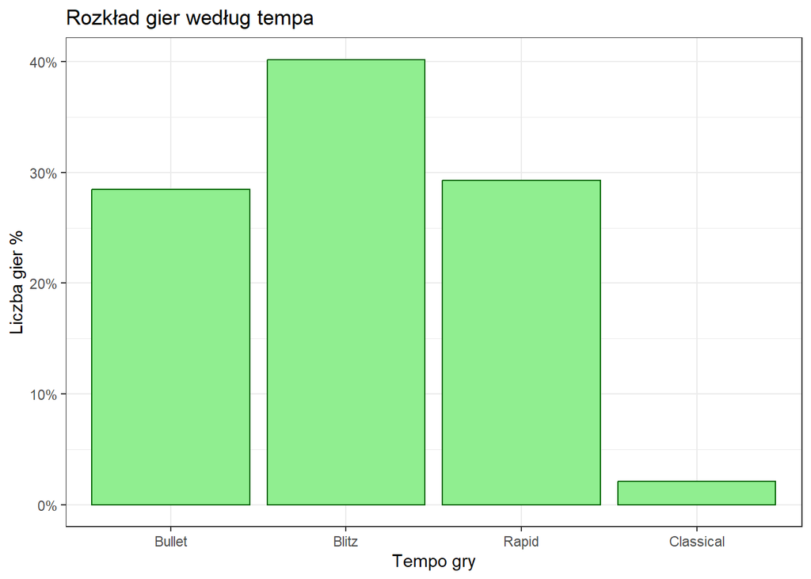

```r
chess %>%
  ggplot() +
  geom_bar(aes(x = reorder(Tempo_gry, Czas_początkowy), y = after_stat(count/sum(count))),
           color = "darkgreen", fill = "lightgreen") +
  theme_bw() +
  scale_y_continuous(labels = percent) +
  labs(title = "Rozkład gier według tempa",
       x = "Tempo gry",
       y = "Liczba gier %")
```

Widzimy że ludzie najmniej grają gier Klasycznych, zaś najbardziej gustują w Blitzach.

## Czas początkowy partii

Wejdźmy głębiej w **tempo gry** i sprawdźmy gry z jakim **czasem początkowym** są najczęściej wybierane przez graczy.

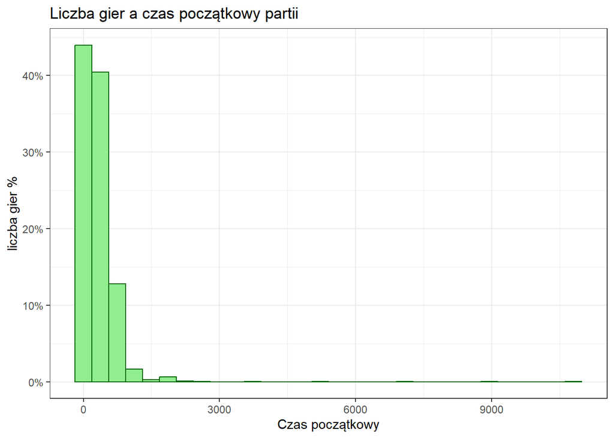

```r
chess %>%
  ggplot() +
  geom_histogram(aes(x = Czas_początkowy, y = after_stat(count/sum(count))),
           color = "darkgreen", fill = "lightgreen") +
  theme_bw() +
  scale_y_continuous(labels = percent)+
  labs(title = "Liczba gier a czas początkowy partii",
       x = "Czas początkowy",
       y = "liczba gier %")
```

Widzimy że jest za dużo wartości odstających żeby wykres był czytelny, możemy jeszcze się upewnić sprawdzając rozkład na *wykresie pudełkowym*.

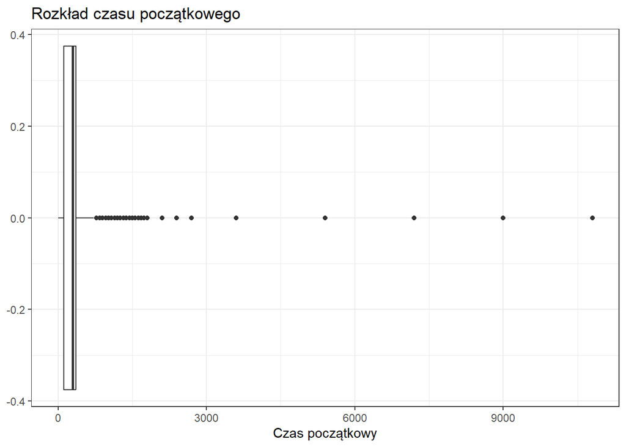

```r
chess %>%
  ggplot(aes(x = Czas_początkowy)) +
  geom_boxplot()+
  theme_bw()+
  labs(title = "Rozkład czasu początkowego",
       x = "Czas początkowy")
```

Niestety nasza hipoteza się potwierdziła. Zamieńmy wartości wieksze niż tysiąc na 1000 aby poprawić czytelność wykresu.

```r
chess$Czas_początkowy[chess$Czas_początkowy>1000] = 1000
```

I wykonajmy ten sam wykres jeszcze raz.

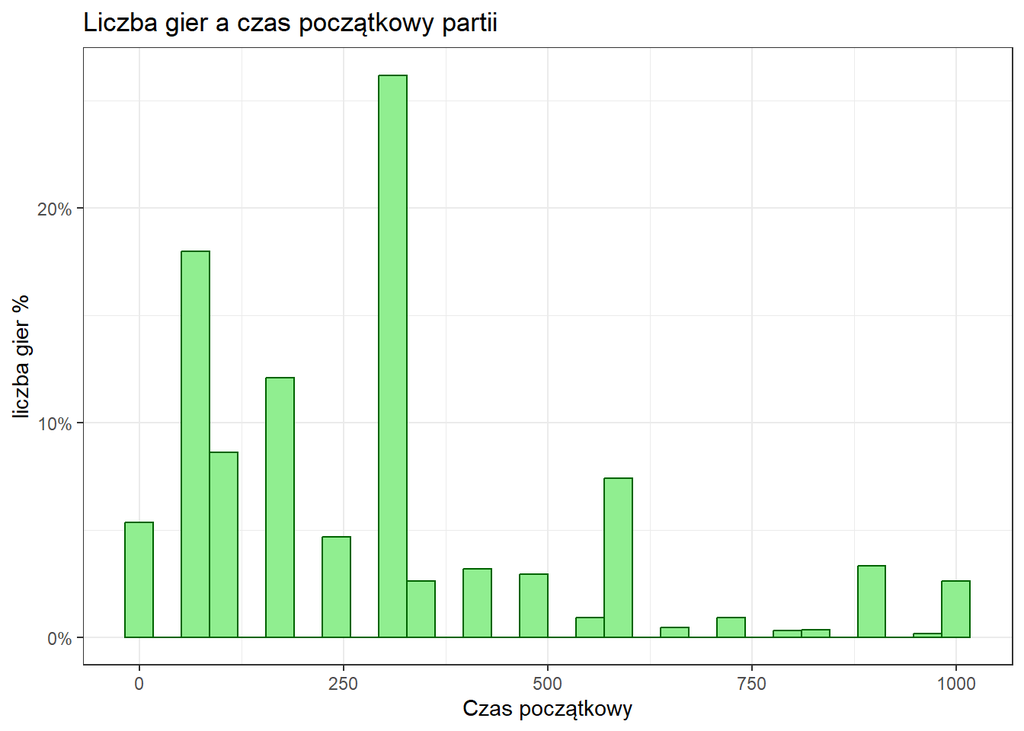

```r
chess %>%
  ggplot() +
  geom_histogram(aes(x = Czas_początkowy, y = after_stat(count/sum(count))),
           color = "darkgreen", fill = "lightgreen") +
  theme_bw() +
  scale_y_continuous(labels = percent)+
  labs(title = "Liczba gier a czas początkowy partii",
       x = "Czas początkowy",
       y = "liczba gier %")
```

Teraz dużo dokładniej widać dane, możemy zauważyć że najwiecej gier jest rozgrywanych dla czasu początkowego około 300sec(5min). Na wykresie widać również partie z czasem początkowym równym zero. Na pierwszy rzut oka wygląda to na jakiś błąd, przyglądnijmy się nim.

```r
czas_0<-chess%>%
  filter(Czas_początkowy==0)%>%
  select(c(Zwycięzca, Zakończenie, Przyrost_czasu, Tempo_gry, Liczba_ruchów, Data, Ranking, Ranking_kat, Typ_otwarcia))
summary(czas_0)
```

```
##  Zwycięzca               Zakończenie    Przyrost_czasu        Tempo_gry
##  Black:26354   Abandoned       :   10   Min.   :  1.000   Blitz    : 1536
##  Draw : 1113   Normal          :20904   1st Qu.:  1.000   Bullet   :54213
##  White:28629   Rules infraction:    2   Median :  1.000   Classical:   31
##                Time forfeit    :35180   Mean   :  1.634   Rapid    :  316
##                                         3rd Qu.:  1.000
##                                         Max.   :180.000
##
##  Liczba_ruchów         Data          Ranking       Ranking_kat
##  Min.   :  1.00   2014-07: 5515   Min.   : 886.5   Niski : 1957
##  1st Qu.: 14.00   2014-06: 5034   1st Qu.:1512.0   Średni:50536
##  Median : 23.00   2014-05: 4647   Median :1672.5   Wysoki: 3603
##  Mean   : 26.15   2014-08: 4565   Mean   :1675.6
##  3rd Qu.: 35.00   2014-10: 4149   3rd Qu.:1838.0
##  Max.   :148.00   2014-11: 4089   Max.   :2674.5
##                   (Other):28097
##       Typ_otwarcia
##  Closed     : 4408
##  Flank      :30269
##  Indian     :  458
##  Open       : 4273
##  Semi-closed:   62
##  Semi-open  :16626
##
```

Widzimy że prawdopodobnie to nie są żadne błędy ani braki danych bo **Przyrost_czasu** przyjmuje wartości od 1, takie gry musiały być bardzo szybkie. Jeśli chodzi o **zakończenie** to myślęże nikogo nie dziwi fakt że wiekszość tych gier skończyło się przez brak czasu. Tak samo jak to że średnia liczba ruchów jest niższa niż w przypadku wszystkich gier.

Spójrzmy jeszcze na zmienną **Tempo_gry**, o dziwo pojawiają się tam nawet gry klasyczne mimo że nie należą one do najkrótszych partii. Rzućmy na nie okiem.

```r
czas_0_classic<-czas_0%>%
  filter(Tempo_gry=="Classical")%>%
  select(c(Zwycięzca, Zakończenie, Przyrost_czasu, Liczba_ruchów, Data, Ranking, Ranking_kat, Typ_otwarcia))
summary(czas_0_classic)
```

```
##  Zwycięzca            Zakończenie Przyrost_czasu  Liczba_ruchów        Data
##  Black:11   Abandoned       : 0   Min.   : 40.0   Min.   : 1.00   2014-07:11
##  Draw : 2   Normal          :13   1st Qu.: 50.0   1st Qu.: 2.00   2014-10: 8
##  White:18   Rules infraction: 0   Median :180.0   Median : 5.00   2014-12: 3
##             Time forfeit    :18   Mean   :126.5   Mean   :15.42   2013-12: 2
##                                   3rd Qu.:180.0   3rd Qu.:24.00   2014-02: 2
##                                   Max.   :180.0   Max.   :69.00   2014-05: 2
##                                                                   (Other): 3
##     Ranking     Ranking_kat      Typ_otwarcia
##  Min.   :1080   Niski : 3   Closed     : 1
##  1st Qu.:1427   Średni:28   Flank      :18
##  Median :1522   Wysoki: 0   Indian     : 0
##  Mean   :1536               Open       : 8
##  3rd Qu.:1630               Semi-closed: 0
##  Max.   :1894               Semi-open  : 4
##
```

Okej, to przez **Przyrost_czasu** który przyjmuje w tych grach wysokie wartości a, on też ma wpływ na **tempo gry**.

Możemy również zauważyć że w takich grach dominuje jednak niższy ranking. Ciekawe jest jednak że średnia liczba ruchów jest dużo niższa niż we wszystkich grach o czasie początkowym zero ale te wnioski mogą być błędne ponieważ mamy bardzo mało danych.

## Ranking a tempo gry

Sprawdźmy teraz jak wygląda *wykres pudełkowy* **rankingu** z podziałem na **tempo gry**.

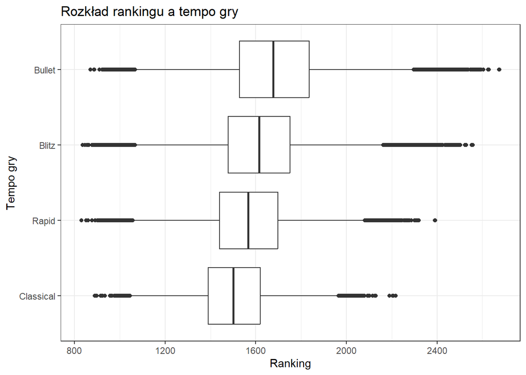

```r
chess %>%
  ggplot(aes(x = reorder(Tempo_gry, Ranking),y = Ranking),
         color = "darkgreen", fill = "lightgreen") +
  geom_boxplot() +
  theme_bw() +
  coord_flip()+
  labs(title = "Rozkład rankingu a tempo gry",
       x = "Tempo gry",
       y = "Ranking")
```

Tutaj widzimy że im krótsze **tempo gry** tym gracze mają średnio wyższy ranking oraz obszar przyjmowanych wartości jest wiekszy.

## Typ otwarcia a zwycięzca

Sprawdźmy czy **typ otwarcia** ma jakiś wpływ na to która ze stron wygra partię.

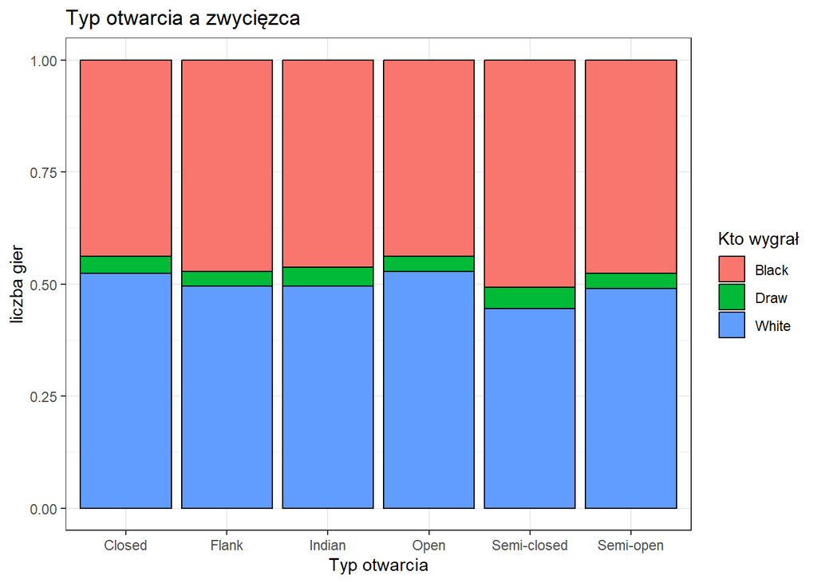

```r
chess %>%
  ggplot() +
  geom_bar(aes(x = Typ_otwarcia, fill = Zwycięzca),
           color = "black",
           position = "fill") +
  theme_bw() +
  labs(title = "Typ otwarcia a zwycięzca",
       x = "Typ otwarcia",
       y = "liczba gier",
       fill = "Kto wygrał")
```

Widać że grając po stronie czarnych warto jest sie pchać w otwarcia pół-zamknięte bo w nich mamy największe prawdopodobieństwo wygranej. Po stronie białej najlepiej się sprawują otwarte oraz zamknięte.

## Poziom rankingu a liczba ruchów

Zobaczmy jeszcze na *wykres gęstości* **liczby ruchów** podzielony na **kategorie rankingu**.

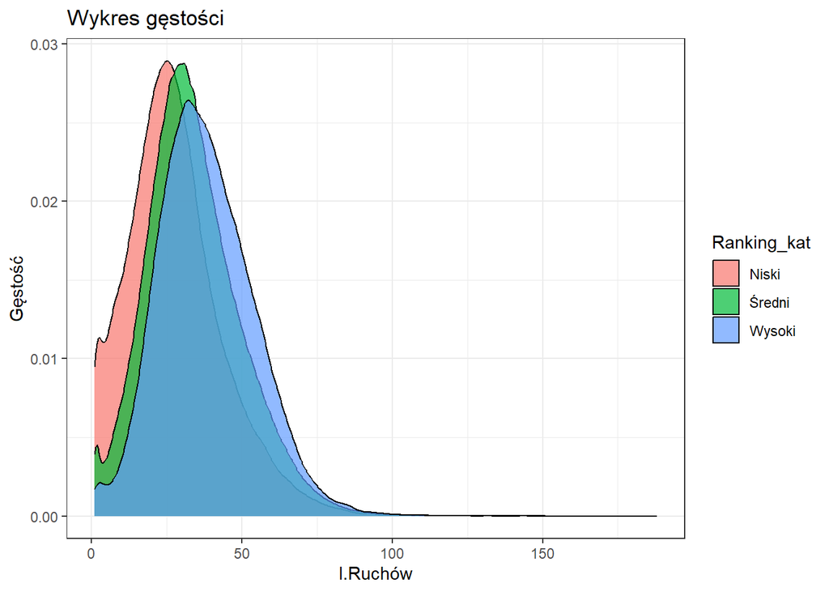

```r
chess %>%
  ggplot(aes(x = Liczba_ruchów, fill = Ranking_kat)) +
  geom_density(alpha = 0.7) +
  theme_bw()+
  labs(title = "Wykres gęstości",
       x = "l.Ruchów",
       y = "Gęstość")
```

Widzimy że **ranking** nie wpływa aż tak bardzo na *gestość rozkładu* ruchów ale jednak możemy powiedziać że im wyższy jest **ranking** graczy tym więcej jest wykonywanych **ruchów** podczas partii.

## Średni ranking na przestrzeni czasu

Sprawdźmy teraz jak zmieniał sie średni **ranking** w czasie na przestrzeni lat 2013-2014.

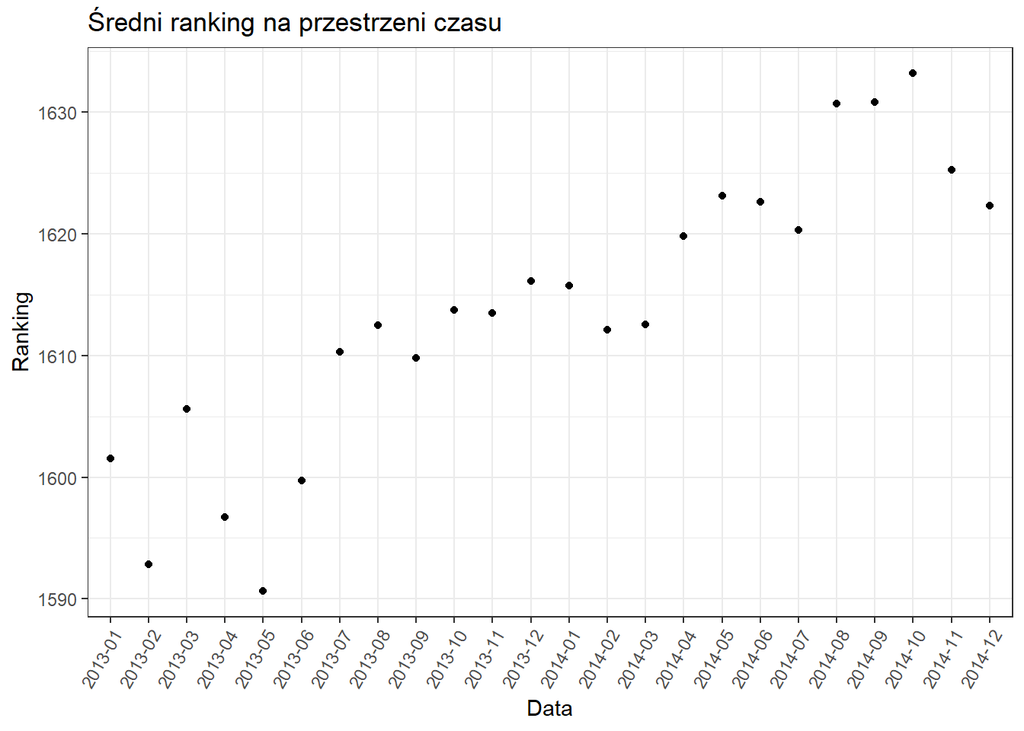

```r
chess %>%
  group_by(Data)%>%
  summarise(mn=mean(Ranking))%>%
  ggplot(aes(x=Data,y=mn))+
  geom_point()+
  theme_bw()+
  theme(axis.text.x = element_text(angle = 60, hjust = 1))+
  labs(title = "Średni ranking na przestrzeni czasu",
       x = "Data",
       y = "Ranking")
```

Na podstawie tego wykresu możemy powiedzieć że średni ranking **rośnie** na przestrzeni lat 2013-2014.

## Czy da się wygrać z dużo wyższym rankingiem od swojego

Wyfiltrujmy teraz partie w których **wygrany ma mniejszy ranking** od swojego przeciwnika o przynajmniej 300.

```r
biały<-chess%>%
  filter(Zwycięzca == "White")%>%
  filter(Ranking_biały + 300<Ranking_czarny)

czarny<-chess%>%
  filter(Zwycięzca == "Black")%>%
  filter(Ranking_biały>Ranking_czarny + 300)

Wygrała_osoba_z_niższym_rankingiem <- rbind(biały, czarny)
```

I sprawdźmy średnią **ilość ruchów** wykonaych w tych partiach oraz we wszystkich.

```r
mean(Wygrała_osoba_z_niższym_rankingiem$Liczba_ruchów)
```

```
## [1] 31.5327
```

```r
mean(chess$Liczba_ruchów)
```

```
## [1] 33.8494
```

Można zauważyć że w grach wygranych przez gracza o **dużo mniejszym rankingu** niż przeciwnik średnio pada **mniej ruchów** niż we wszystkich grach.

Sprawdźmy również ile wynosi stosunek takich partii do wszystkich.

```r
sum(Wygrała_osoba_z_niższym_rankingiem$Ranking>0)/sum(chess$Ranking>0)
```

```
## [1] 0.01547147
```

1,5% - nie jest to dużo ale jest szansa wygrać partię gdy przeciwnik ma dużo większy ranking od ciebie. **Nie poddawaj sie!**

## Średni ranking a typ otwarcia

Sprawdźmy ile wynosi **średni ranking** w zależności od **rodzaju otwarcia**.

*Zaraz święta więc użyjmy śnieżynek zamiast zwykłych punktów :).*

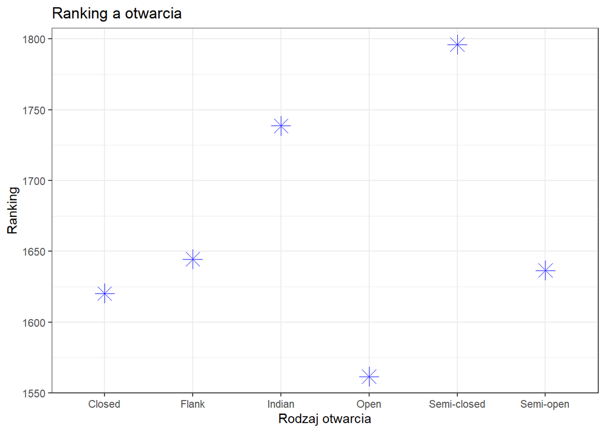

```r
chess %>%
  group_by(Typ_otwarcia)%>%
  summarise(mn=mean(Ranking))%>%
  ggplot(aes(x=Typ_otwarcia,y=mn))+
  geom_point(size = 5, shape = 8, color = "blue")+
  theme_bw() +
  labs(title = "Ranking a otwarcia",
       x = "Rodzaj otwarcia",
       y = "Ranking")
```

Wykres pokazuje że średnio osoby mające najwyższy ranking grają otwarcia *pół-zamknięte*, a zaraz za nimi *otwarcia Indyjskie*. Natomiast otwarcia *otwarte* są najczęściej wybierane przez osoby z niższym rankingiem.

Zobaczmy jeszcze podobną zależność tylko weźmy **ranking** jako *zmienna kategoryczną* oraz wybierzmy trochę inny wykres.

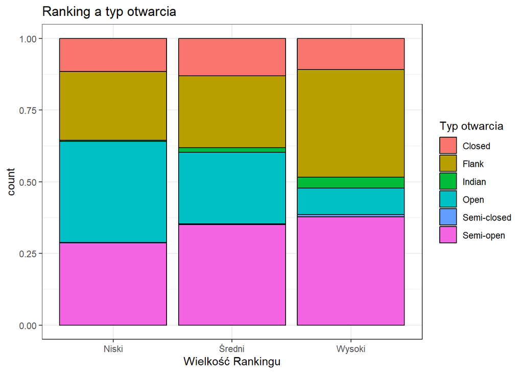

```r
chess %>%
  ggplot() +
  geom_bar(aes(x = Ranking_kat, fill = Typ_otwarcia),
           color = "black",
           position = "fill") +
  theme_bw() +
  labs(title = "Ranking a typ otwarcia",
       x = "Wielkość Rankingu",
       fill = "Typ otwarcia")
```

Na podstawie tego wykresu możemy wyciągnąc bardzo ciekawe wnioski. Widać że wraz ze **wzrostem rankingu** gracze berdziej skłaniają sie do wyboru otwarć *pół-otwartych*, *Indyjskich* oraz *skrzydłowych(Flank)*, a rzadziej wybierają otwarcia *otwarte*, natomiast otwarcia *zamknięte* oraz *pół-zamknięte* w zasadzie pozostają **bez zmian**.

## Ranking każdego z graczy a wygrany

Na koniec porównajmy rankingi obydwu graczy i zobaczmy który wygrał.

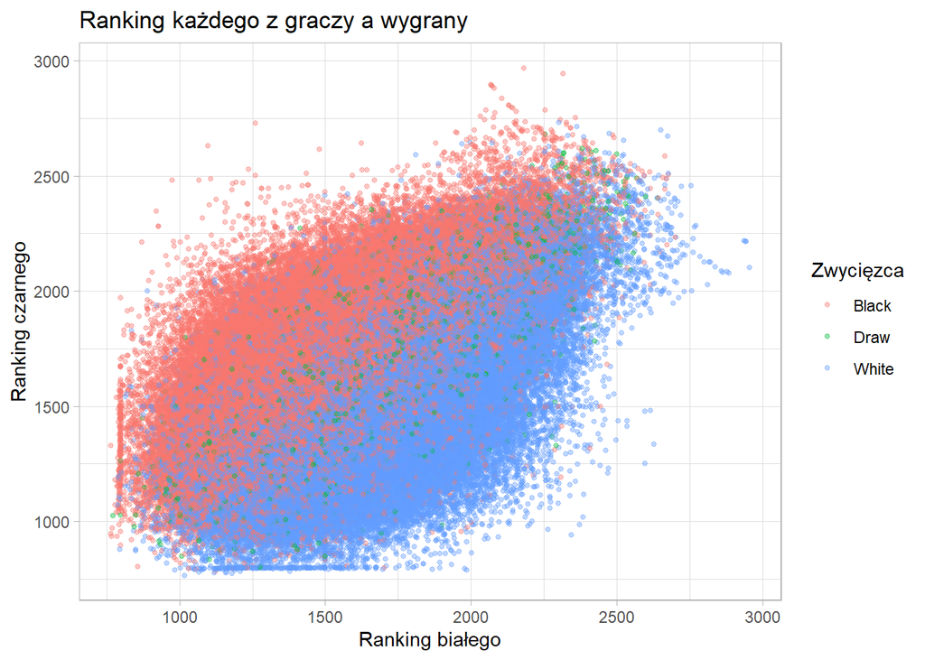

```r
chess %>%
  ggplot() +
  geom_point(aes(x = Ranking_biały, y = Ranking_czarny, col = Zwycięzca),
             size = 1, alpha = 0.4) +
  theme_light() +
  labs(title = "Ranking każdego z graczy a wygrany",
       x = "Ranking białego",
       y = "Ranking czarnego")
```

I jak można było się spodziewać im większa przewaga rankingu jednego z graczy nad drugim tym częściej on wygrywa.

## Podsumowanie

Myślę że ta analiza danych szachowych pomogła rozjaśnić i przybliżyć ci wiele kwestii związanych z szachami. Jest to gra bardzo ciekawa oraz rozwijająca i polecam każdemu rozpoczęcie z nią swojej przygody.